# Data visualization in R

Below we plot unemployment rate vs. length of unemployment and join the individual observations with a path. Because of the many line crossings, the direction in which time flows isn’t easy to see in the first plot. In the second plot, we color the points to make it easier to see the direction of time.

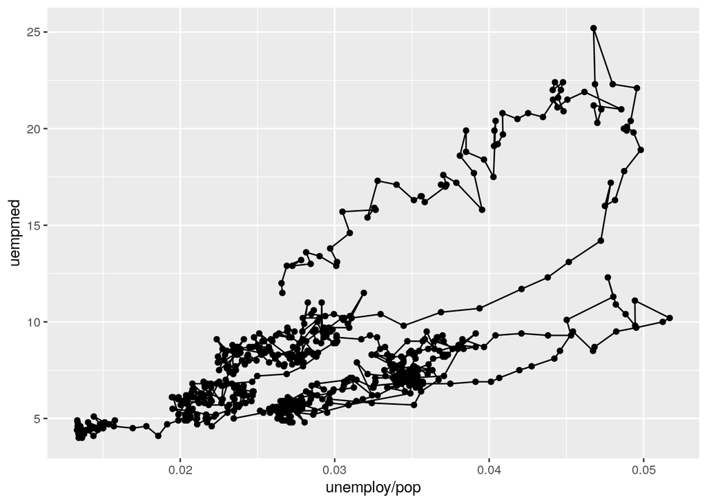

```r
ggplot(economics, aes(unemploy / pop, uempmed)) +
  geom_path() +
  geom_point()
```

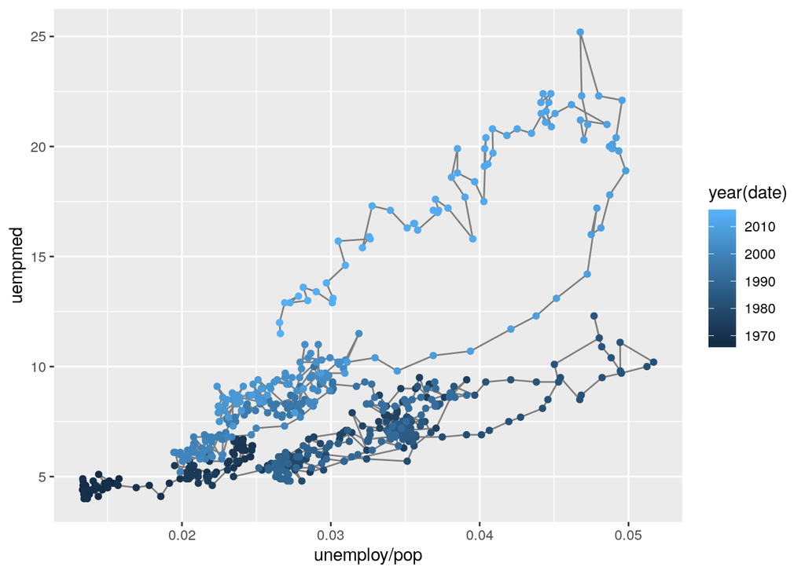

```r
year <- function(x) as.POSIXlt(x)$year + 1900
ggplot(economics, aes(unemploy / pop, uempmed)) +
  geom_path(color = "grey50") +
  geom_point(aes(color = year(date)))
```

We can see that unemployment rate and length of unemployment are highly correlated, but in recent years the length of unemployment has been increasing relative to the unemployment rate.

With longitudinal data, you often want to display multiple time series on each plot, each series representing one individual. To do this you need to map the `group` aesthetic to a variable encoding the group membership of each observation.

### Exercises

1. What’s the problem with the plot created by `ggplot(mpg, aes(cty, hwy)) + geom_point()`? Which of the geoms described above is most effective at remedying the problem?
2. One challenge with `ggplot(mpg, aes(class, hwy)) + geom_boxplot()` is that the ordering of `class` is alphabetical, which is not terribly useful. How could you change the factor levels to be more informative?

   Rather than reordering the factor by hand, you can do it automatically based on the data: `ggplot(mpg, aes(reorder(class, hwy), hwy)) + geom_boxplot()`. What does `reorder()` do? Read the documentation.
3. Explore the distribution of the carat variable in the `diamonds` dataset. What binwidth reveals the most interesting patterns?
4. Explore the distribution of the price variable in the `diamonds` data. How does the distribution vary by cut?
5. You now know (at least) three ways to compare the distributions of subgroups: `geom_violin()`, `geom_freqpoly()` and the color aesthetic, or `geom_histogram()` and facetting. What are the strengths and weaknesses of each approach? What other approaches could you try?
6. Read the documentation for `geom_bar()`. What does the `weight` aesthetic do?
7. Using the techniques already discussed in this workshop, come up with three ways to visualise a 2d categorical distribution. Try them out by visualising the distribution of `model` and `manufacturer`, `trans` and `class`, and `cyl` and `trans`.

## Modifying the axes

Two families of useful helpers let you make the most common axes modifications. `xlab()` and `ylab()` modify the x- and y-axis labels:

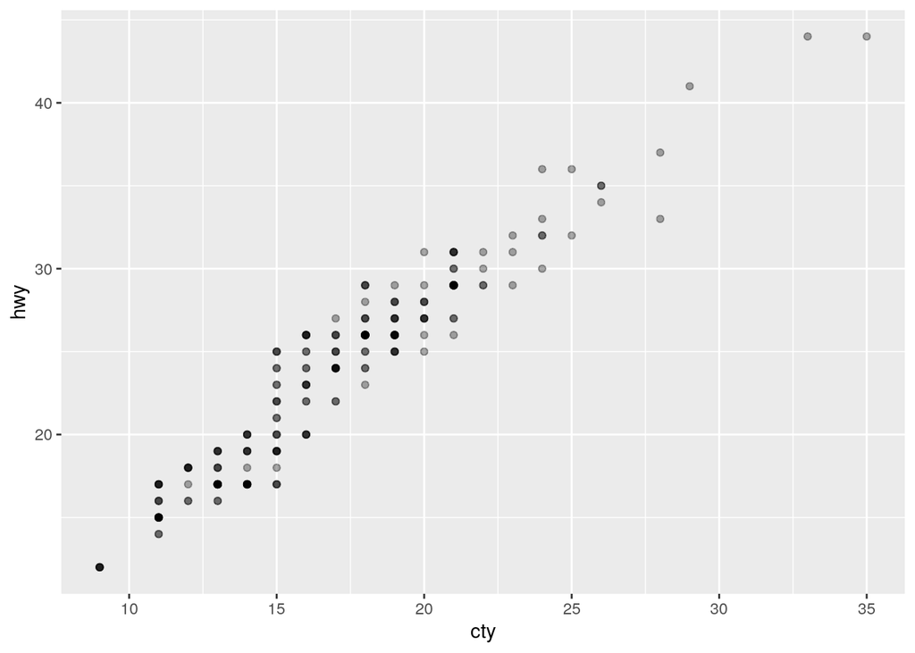

```r
ggplot(mpg, aes(cty, hwy)) +
  geom_point(alpha = 1 / 3)
```

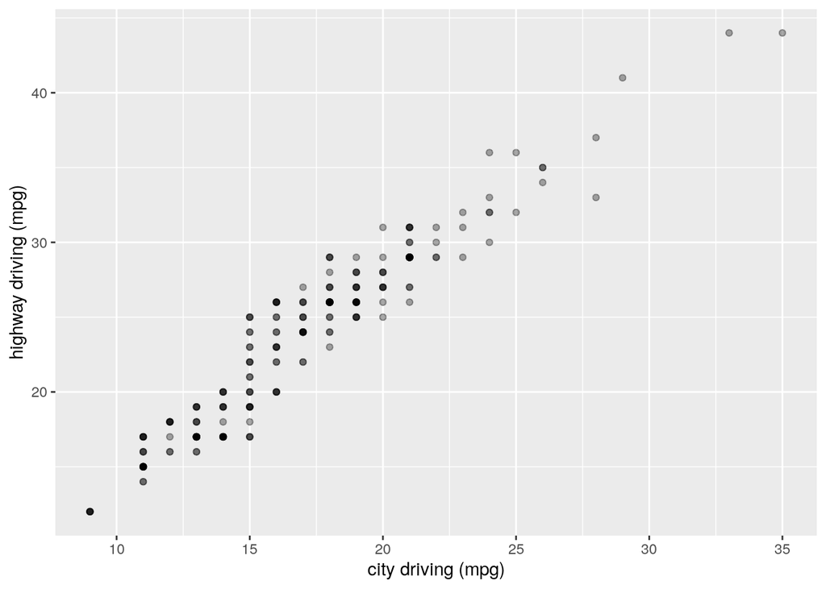

```r
ggplot(mpg, aes(cty, hwy)) +
  geom_point(alpha = 1 / 3) +
  xlab("city driving (mpg)") +
  ylab("highway driving (mpg)")
```

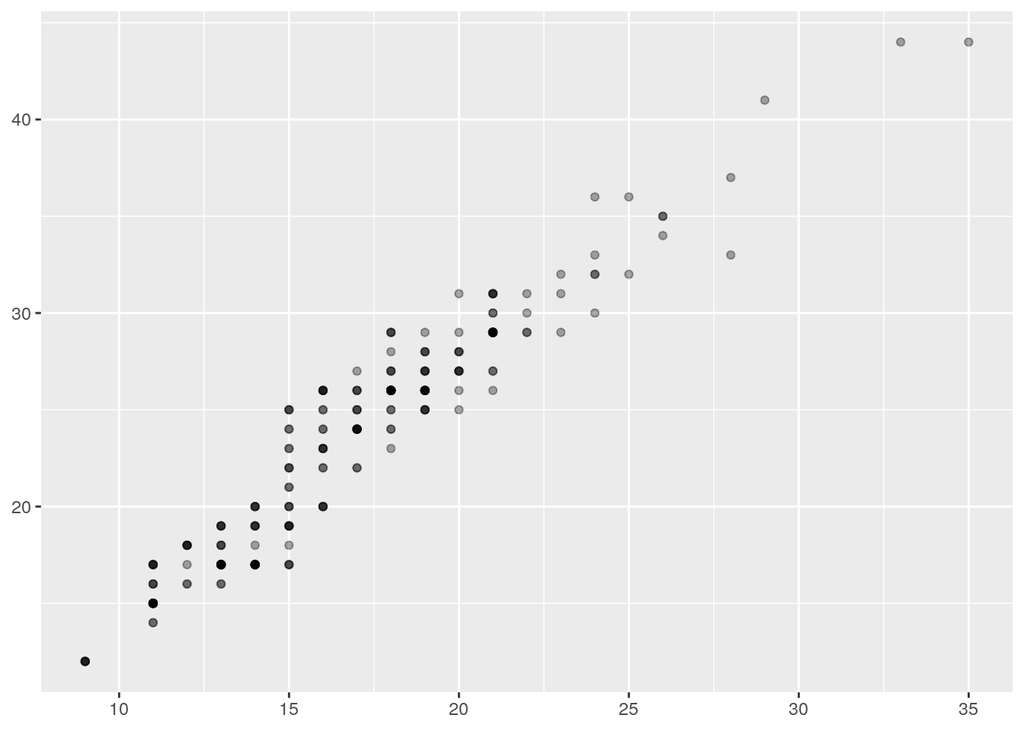

```r
# Remove the axis labels with NULL
ggplot(mpg, aes(cty, hwy)) +
  geom_point(alpha = 1 / 3) +
  xlab(NULL) +
  ylab(NULL)
```

`xlim()` and `ylim()` modify the limits of axes:

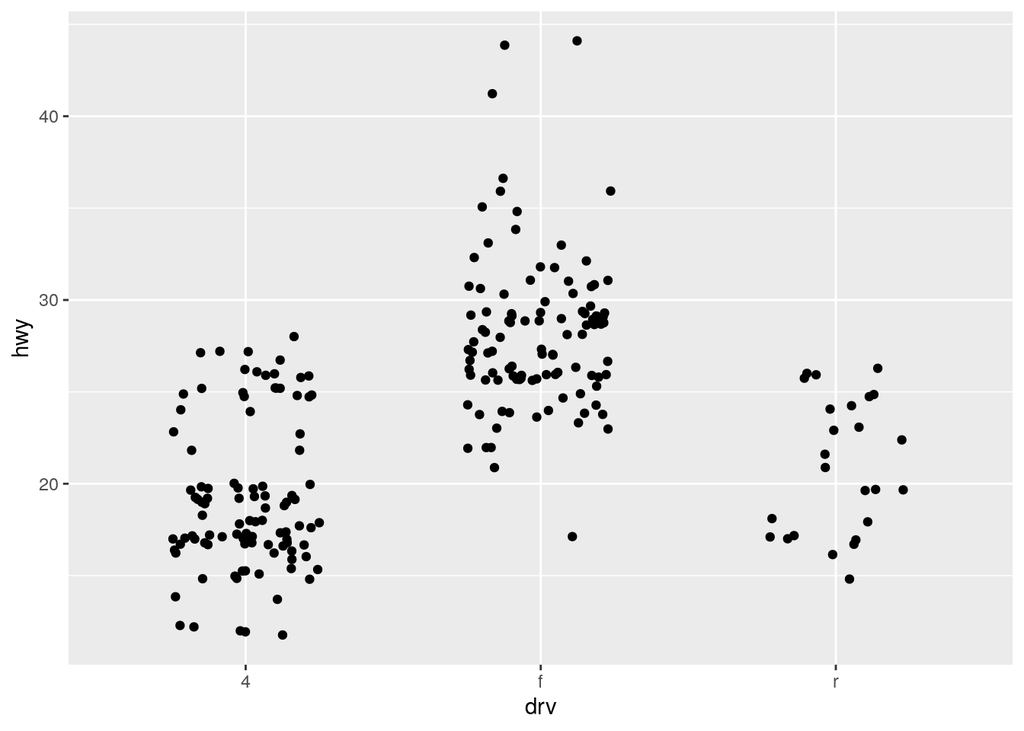

```r
ggplot(mpg, aes(drv, hwy)) +
  geom_jitter(width = 0.25)
```

[output not shown]

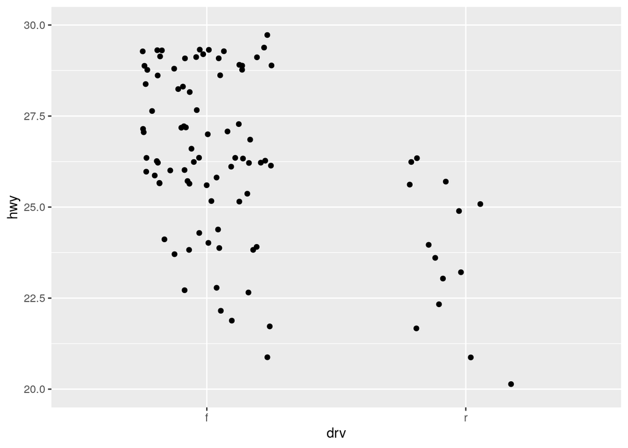

```r
ggplot(mpg, aes(drv, hwy)) +
  geom_jitter(width = 0.25) +
  xlim("f", "r") +
  ylim(20, 30)
```

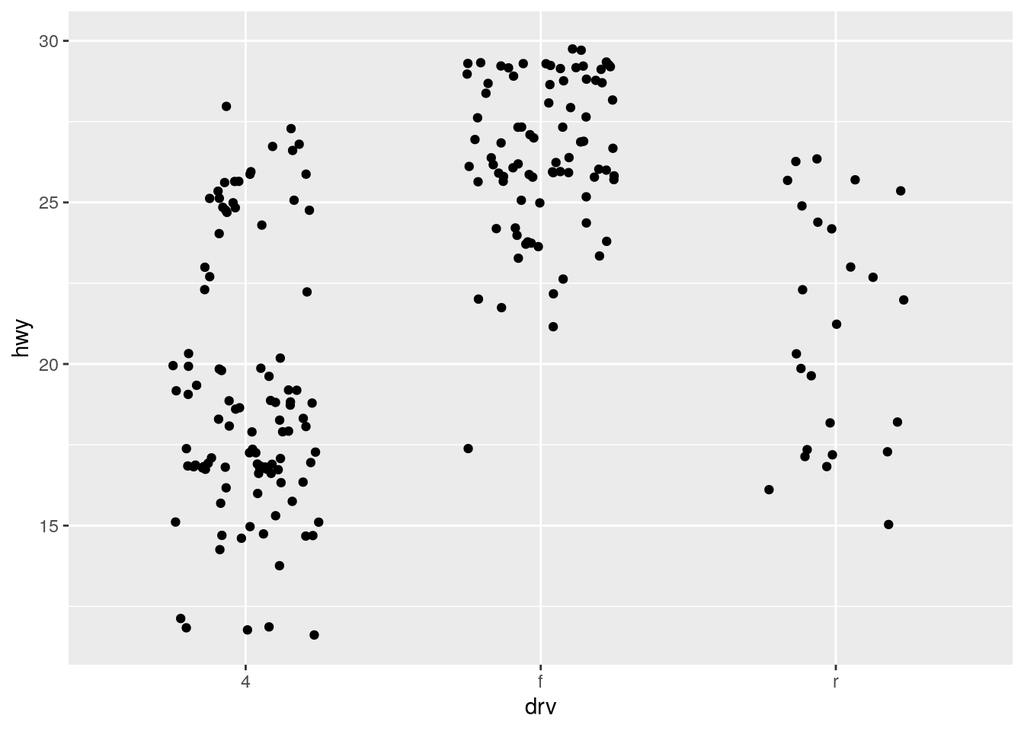

```r
# For continuous scales, use NA to set only one limit
ggplot(mpg, aes(drv, hwy)) +
  geom_jitter(width = 0.25, na.rm = TRUE) +
  ylim(NA, 30)
```

Changing the axes limits sets values outside the range to `NA`. You can suppress the associated warning with `na.rm = TRUE`, but be careful. If your plot calculates summary statistics (e.g., sample mean), this conversion to `NA` occurs *before* the summary statistics are computed, and may lead to undesirable results in some situations.

## Output

Most of the time you create a plot object and immediately plot it, but you can also save a plot to a variable and manipulate it:

```r
p <- ggplot(mpg, aes(displ, hwy, color = factor(cyl))) +
  geom_point()
```

Once you have a plot object, there are a few things you can do with it:

- Render it on screen with `print()`. This happens automatically when running interactively, but inside a loop or function, you’ll need to `print()` it yourself.

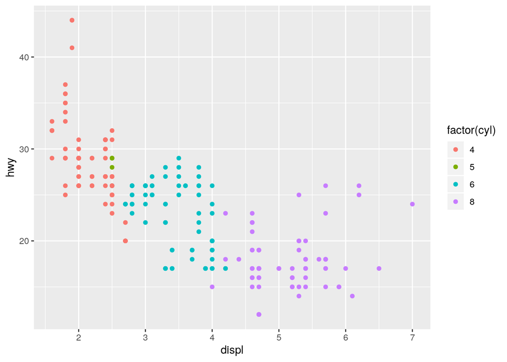

  ```r
  print(p)
  ```

- Save it to disk with `ggsave()`.

  ```r
  # Save png to disk
  ggsave("plot.png", p, width = 5, height = 5)
  ```

- Briefly describe its structure with `summary()`.

  ```r
  summary(p)
  ```

  ```
  ## data: manufacturer, model, displ, year, cyl, trans, drv, cty, hwy,
  ##   fl, class [234x11]
  ## mapping:  x = ~displ, y = ~hwy, colour = ~factor(cyl)
  ## faceting: <ggproto object: Class FacetNull, Facet, gg>
  ##     compute_layout: function
  ##     draw_back: function
  ##     draw_front: function
  ##     draw_labels: function
  ##     draw_panels: function
  ##     finish_data: function
  ##     init_scales: function
  ##     map_data: function
  ##     params: list
  ##     setup_data: function
  ##     setup_params: function
  ##     shrink: TRUE
  ##     train_scales: function
  ##     vars: function
  ##     super:  <ggproto object: Class FacetNull, Facet, gg>
  ## -----------------------------------
  ## geom_point: na.rm = FALSE
  ## stat_identity: na.rm = FALSE
  ## position_identity
  ```

- Save a cached copy of it to disk, with `saveRDS()`. This saves a complete copy of the plot object, so you can easily re-create it with `readRDS()`.

  ```r
  saveRDS(p, "plot.rds")
  q <- readRDS("plot.rds")
  ```

## Conclusion

Congratualions! You’ve now worked through “Getting started with ggplot2” from Hadley Wickham’s book, [ggplot2: Elegant Graphics for Data Analysis](https://ggplot2-book.org/). Be sure to check out the other chapters for more advanced features of `ggplot2` and an in-depth discussion of the layered grammer of graphics.

To further your learning be sure to check out the following free(!) online resources:

- [The R Graph Gallery](https://www.r-graph-gallery.com/): Extremely useful repository of data visualizations and the R code necessary to implement them.
- [From Data to Viz](https://www.data-to-viz.com/): Struggling to figure out which data visualization to use for your dataset? This decision tree will help you figure it out!
- [RStudio Primers](https://rstudio.cloud/learn/primers): A quick and dirty introduction to the tidyverse, a suite of data science packages that are engineered to play well together in R.
- [RStudio Cheat Sheets](https://rstudio.cloud/learn/cheat-sheets): Cheat sheets of the some most common tasks in R. Print these out and hang them on your wall for quick reference!
- [R for Data Science book](https://r4ds.had.co.nz/): The defacto book for learning how to do data science in R (for good reason).
- [R Graphics Cookbook](https://r-graphics.org/): “Recipes” for all the data visualizations your heart desires!

You can also plug into a community of R enthusiasts within the GC and globally!

- [GC Digital Initiatives](https://gcdi.commons.gc.cuny.edu/calendar/): Keep an eye on the GCDI calendar to learn about user groups, workshops, office hours, and more!
- [R Users’ Group](https://commons.gc.cuny.edu/groups/rug-r-users-group/): Working group at the GC focused on R… welcomes users of all skill levels!
- [R for Data Science Slack Group](https://www.rfordatasci.com/): Working through the R for Data Science book? Join this slack group to get help with all your questions!

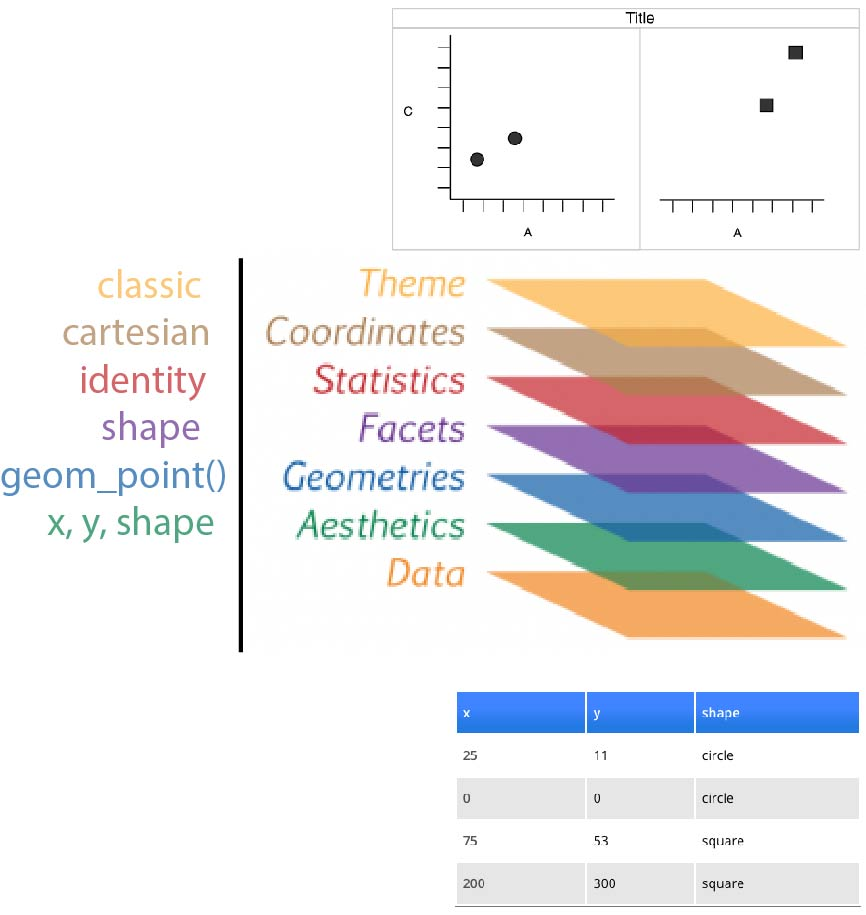